# SolutionsForHomework3

## Mathematics in the Real World

### Solutions for Homework 3

#### Prof. Jack Poulson; May 21, 2015

#### Problem 1

Given the system of equations $$ \begin{pmatrix} 1 & 2 & 3 \\ 2 & 5 & 2 \\ 3 & 4 & 5 \end{pmatrix} \begin{bmatrix} x_1 \\ x_2 \\ x_3 \end{bmatrix} = \begin{bmatrix} 5 \\ 6 \\ 7 \end{bmatrix}, $$

**a)** Perform Gaussian Elimination to put the system of equations into upper-triangular form.

**b)** Perform back substitution to find $x_3$, $x_2$, and then $x_1$.

##### Part (a)

Since our goal is to "zero" the entries of the matrix below the main diagonal, we start by subtracting $2/1$ times the first equation from the second equation, and $3/1$ times the first equation from the third equation to find: $$ \begin{pmatrix} 1 & 2 & 3 \\ 0 & 1 & -4 \\ 0 & -2 & -4 \end{pmatrix} \begin{bmatrix} x_1 \\ x_2 \\ x_3 \end{bmatrix} = \begin{bmatrix} 5 \\ -4 \\ -8 \end{bmatrix}. $$ The remaining entry can be zeroed by subtracting $-2/1$ times the second row from the third row and finding $$ \begin{pmatrix} 1 & 2 & 3 \\ 0 & 1 & -4 \\ 0 & 0 & -12 \end{pmatrix} \begin{bmatrix} x_1 \\ x_2 \\ x_3 \end{bmatrix} = \begin{bmatrix} 5 \\ -4 \\ -16 \end{bmatrix}. $$

##### Part(b)

The first step of backwards substitution immediately tells us that $$ x_3 = \frac{4}{3}, $$ and the second then solves for $x_2$ in $$ x_2 - 4 x_3 = -4, $$ and finds $$ x_2 = -4 + 4 x_3 = -4 + \frac{16}{3} = \frac{4}{3}. $$ Lastly, we then solve $$ x_1 + 2 x_2 + 3 x_3 = 5 $$ to find $$ x_1 = 5 - 2 x_2 - 3 x_3 = 5 - \frac{8}{3} - \frac{12}{3} = -\frac{5}{3}. $$

We can plug these values into the equation $$ r = b - A x $$ to find that the **residual**, $r$, is zero, which shows that the chosen parameters properly predict the data.

#### Problem 2

Given the matrix $$ A = \begin{pmatrix} 1 & 7 & 8 & 3 \\ 2 & 4 & 2 & 1 \end{pmatrix}, $$

**a)** Write down the transpose of $A$ (which is denoted $A^T$).

**b)** Compute $C = A^T A$.

##### Part (a)

The transpose is $$ \begin{pmatrix} 1 & 2 \\ 7 & 4 \\ 8 & 2 \\ 3 & 1 \end{pmatrix}. $$

##### Part (b)

The product is $$ \begin{pmatrix} 1 & 2 \\ 7 & 4 \\ 8 & 2 \\ 3 & 1 \end{pmatrix} \begin{pmatrix} 1 & 7 & 8 & 3 \\ 2 & 4 & 2 & 1 \end{pmatrix} = \begin{pmatrix} 5 & 15 & 12 & 5 \\ 15 & 65 & 64 & 25 \\ 12 & 64 & 68 & 26 \\ 5 & 25 & 26 & 10 \end{pmatrix}. $$

#### Problem 3

Given the measurements $(5,4,5,5,10,7)$, respectively occuring at times $(0,1,2,3,4,5)$:

**a)** Compute the "best" (with respect to the two-norm) **linear** fit of the dataset.

**b)** Compute the "best" (with respect to the two-norm) **quadratic** fit of the dataset.

##### Part (a)

Use $$ A = \begin{pmatrix} 1 & 0 \\ 1 & 1 \\ 1 & 2 \\ 1 & 3 \\ 1 & 4 \\ 1 & 5 \end{pmatrix}, \quad b = \begin{bmatrix} 5 \\ 4 \\ 5 \\ 5 \\ 10 \\ 7 \end{bmatrix}$$ to set up the normal equations $$ A^T A x = A^T b, $$ or, in our case, $$ \begin{pmatrix} 6 & 15 \\ 15 & 55 \end{pmatrix} \begin{bmatrix} x_1 \\ x_2 \end{bmatrix} = \begin{bmatrix} 36 \\ 104 \end{bmatrix}, $$ which has a solution (e.g., through Gaussian Elimination) of $$ x_1 = 4,\quad x_2 = \frac{4}{5}. $$ The implied linear fit is thus $$ \ell(t) = 4 + \frac{4}{5} t. $$

##### Part (b)

$$ A = \begin{pmatrix} 1 & 0 & 0 \\ 1 & 1 & 1 \\ 1 & 2 & 4 \\ 1 & 3 & 9 \\ 1 & 4 & 16 \\ 1 & 5 & 25 \end{pmatrix}, \quad \begin{bmatrix} 5 \\ 4 \\ 5 \\ 5 \\ 10 \\ 7 \end{bmatrix}$$

```
(3, 11)
```

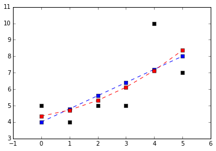

```python
%matplotlib inline
import numpy as np
import matplotlib.pyplot as plt

b = [5,4,5,5,10,7];
ALin = [[1,0],[1,1],[1,2],[1,3],[1,4],[1,5]]
AQuad = [[1,0,0],[1,1,1],[1,2,4],[1,3,9],[1,4,16],[1,5,25]]
xLin = [4,0.8]
xQuad = [4.35714,0.26429,0.10714]
yLin = np.dot(ALin,xLin)
yQuad = np.dot(AQuad,xQuad)
t = [0,1,2,3,4,5]
plt.plot(t,b,'ks',t,yLin,'bs--',t,yQuad,'rs--')
plt.xlim((-1,6))
plt.ylim((3,11))
```